# Model selection: Hitters Notebook

Bikramjit Das

2024

# 1 Data set

The hitters data set consists of 322 observations on 21 variables with the following information - `X` (name), `AtBat`, `Hits`, `HmRun` (home runs), `Runs`, `RBI`, `Walks`, `Years`, `CAtBat`, `CHits`, `CHmRun`, `CRuns`, `CRBI`, `CWalks`, `League`, `Division`, `PutOuts`, `Assists`, `Errors`, `Salary`, `NewLeague`. Here `League`, `Division` and `NewLeague` are factor variables with 2 categories. We drop rows with missing entries and are left with 263 observations.

```r
rm(list=ls())
hitter <- read.csv("hitters.csv")
str(hitter)
hitter<-na.omit(hitter)
str(hitter)
```

# 2 Subset selection

The `leaps` package in R does subset selection with the `regsubsets` function.

```r
#install.packages("leaps")
library(leaps)
?regsubsets
```

## 2.1 Best subset

For best subset selection no `method` needs to be specified (alternatively specify `method="exhaustive"`). By default, the maximum number of subsets this function uses is 8. We extend this to do a complete subset selection by changing the default value of `nvmax` argument in this function. Note that `CRBI` is in the model with 1 to 6 variables but not in the model with 7 and 8 variables.

```r
hitters <- hitter[,2:21] # remove the name variable

modelb <- regsubsets(Salary~.,hitters)  ## Best subset up to size 8
summary(modelb)
```

```
## Subset selection object
## Call: regsubsets.formula(Salary ~ ., hitters)
## 19 Variables  (and intercept)
##            Forced in Forced out
## AtBat          FALSE      FALSE
## Hits           FALSE      FALSE
## HmRun          FALSE      FALSE
## Runs           FALSE      FALSE
## RBI            FALSE      FALSE
## Walks          FALSE      FALSE
## Years          FALSE      FALSE
## CAtBat         FALSE      FALSE
## CHits          FALSE      FALSE
## CHmRun         FALSE      FALSE
## CRuns          FALSE      FALSE
## CRBI           FALSE      FALSE
## CWalks         FALSE      FALSE
## LeagueN        FALSE      FALSE
## DivisionW      FALSE      FALSE
## PutOuts        FALSE      FALSE
## Assists        FALSE      FALSE
## Errors         FALSE      FALSE
## NewLeagueN     FALSE      FALSE
## 1 subsets of each size up to 8
## Selection Algorithm: exhaustive
##          AtBat Hits HmRun Runs RBI Walks Years CAtBat CHits CHmRun CRuns CRBI
## 1  ( 1 ) " "   " "  " "   " "  " " " "   " "   " "    " "   " "    " "   "*"
## 2  ( 1 ) " "   "*"  " "   " "  " " " "   " "   " "    " "   " "    " "   "*"
## 3  ( 1 ) " "   "*"  " "   " "  " " " "   " "   " "    " "   " "    " "   "*"
## 4  ( 1 ) " "   "*"  " "   " "  " " " "   " "   " "    " "   " "    " "   "*"
## 5  ( 1 ) "*"   "*"  " "   " "  " " " "   " "   " "    " "   " "    " "   "*"
## 6  ( 1 ) "*"   "*"  " "   " "  " " "*"   " "   " "    " "   " "    " "   "*"
## 7  ( 1 ) " "   "*"  " "   " "  " " "*"   " "   "*"    "*"   "*"    " "   " "
## 8  ( 1 ) "*"   "*"  " "   " "  " " "*"   " "   " "    " "   "*"    "*"   " "
##          CWalks LeagueN DivisionW PutOuts Assists Errors NewLeagueN
## 1  ( 1 ) " "    " "     " "       " "     " "     " "    " "
## 2  ( 1 ) " "    " "     " "       " "     " "     " "    " "
## 3  ( 1 ) " "    " "     " "       "*"     " "     " "    " "
## 4  ( 1 ) " "    " "     "*"       "*"     " "     " "    " "
## 5  ( 1 ) " "    " "     "*"       "*"     " "     " "    " "
## 6  ( 1 ) " "    " "     "*"       "*"     " "     " "    " "
## 7  ( 1 ) " "    " "     "*"       "*"     " "     " "    " "
## 8  ( 1 ) "*"    " "     "*"       "*"     " "     " "    " "
```

```r
modelbest<-regsubsets(Salary~.,hitters,nvmax=19)
summary(modelbest)
```

```
## Subset selection object
## Call: regsubsets.formula(Salary ~ ., hitters, nvmax = 19)
## 19 Variables  (and intercept)
##            Forced in Forced out
## AtBat          FALSE      FALSE
## Hits           FALSE      FALSE
## HmRun          FALSE      FALSE
## Runs           FALSE      FALSE
## RBI            FALSE      FALSE
## Walks          FALSE      FALSE
## Years          FALSE      FALSE
## CAtBat         FALSE      FALSE
## CHits          FALSE      FALSE
## CHmRun         FALSE      FALSE
## CRuns          FALSE      FALSE
## CRBI           FALSE      FALSE
## CWalks         FALSE      FALSE
## LeagueN        FALSE      FALSE
## DivisionW      FALSE      FALSE
## PutOuts        FALSE      FALSE
## Assists        FALSE      FALSE
## Errors         FALSE      FALSE
## NewLeagueN     FALSE      FALSE
## 1 subsets of each size up to 19
## Selection Algorithm: exhaustive
##           AtBat Hits HmRun Runs RBI Walks Years CAtBat CHits CHmRun CRuns CRBI
## 1  ( 1 )  " "   " "  " "   " "  " " " "   " "   " "    " "   " "    " "   "*"
## 2  ( 1 )  " "   "*"  " "   " "  " " " "   " "   " "    " "   " "    " "   "*"
## 3  ( 1 )  " "   "*"  " "   " "  " " " "   " "   " "    " "   " "    " "   "*"
## 4  ( 1 )  " "   "*"  " "   " "  " " " "   " "   " "    " "   " "    " "   "*"
## 5  ( 1 )  "*"   "*"  " "   " "  " " " "   " "   " "    " "   " "    " "   "*"
## 6  ( 1 )  "*"   "*"  " "   " "  " " "*"   " "   " "    " "   " "    " "   "*"
## 7  ( 1 )  " "   "*"  " "   " "  " " "*"   " "   "*"    "*"   "*"    " "   " "
## 8  ( 1 )  "*"   "*"  " "   " "  " " "*"   " "   " "    " "   "*"    "*"   " "
## 9  ( 1 )  "*"   "*"  " "   " "  " " "*"   " "   "*"    " "   " "    "*"   "*"
## 10  ( 1 ) "*"   "*"  " "   " "  " " "*"   " "   "*"    " "   " "    "*"   "*"
## 11  ( 1 ) "*"   "*"  " "   " "  " " "*"   " "   "*"    " "   " "    "*"   "*"
## 12  ( 1 ) "*"   "*"  " "   "*"  " " "*"   " "   "*"    " "   " "    "*"   "*"
## 13  ( 1 ) "*"   "*"  " "   "*"  " " "*"   " "   "*"    " "   " "    "*"   "*"
## 14  ( 1 ) "*"   "*"  "*"   "*"  " " "*"   " "   "*"    " "   " "    "*"   "*"
```

[output cut: 10 more lines]

```
## 5  ( 1 )  " "    " "     "*"       "*"     " "     " "    " "
## 6  ( 1 )  " "    " "     "*"       "*"     " "     " "    " "
## 7  ( 1 )  " "    " "     "*"       "*"     " "     " "    " "
## 8  ( 1 )  "*"    " "     "*"       "*"     " "     " "    " "
## 9  ( 1 )  "*"    " "     "*"       "*"     " "     " "    " "
## 10  ( 1 ) "*"    " "     "*"       "*"     "*"     " "    " "
## 11  ( 1 ) "*"    "*"     "*"       "*"     "*"     " "    " "
## 12  ( 1 ) "*"    "*"     "*"       "*"     "*"     " "    " "
## 13  ( 1 ) "*"    "*"     "*"       "*"     "*"     "*"    " "
## 14  ( 1 ) "*"    "*"     "*"       "*"     "*"     "*"    " "
## 15  ( 1 ) "*"    "*"     "*"       "*"     "*"     "*"    " "
## 16  ( 1 ) "*"    "*"     "*"       "*"     "*"     "*"    " "
## 17  ( 1 ) "*"    "*"     "*"       "*"     "*"     "*"    "*"
## 18  ( 1 ) "*"    "*"     "*"       "*"     "*"     "*"    "*"
## 19  ( 1 ) "*"    "*"     "*"       "*"     "*"     "*"    "*"
```

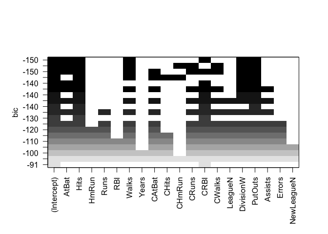

```r
plot(modelbest)  ### Plot with Bayesian Information Criterion  = -2LL + p log(n) ## p: number of parameters
```

```r
names(summary(modelbest))
```

```
## [1] "which"  "rsq"    "rss"    "adjr2"  "cp"     "bic"    "outmat" "obj"
```

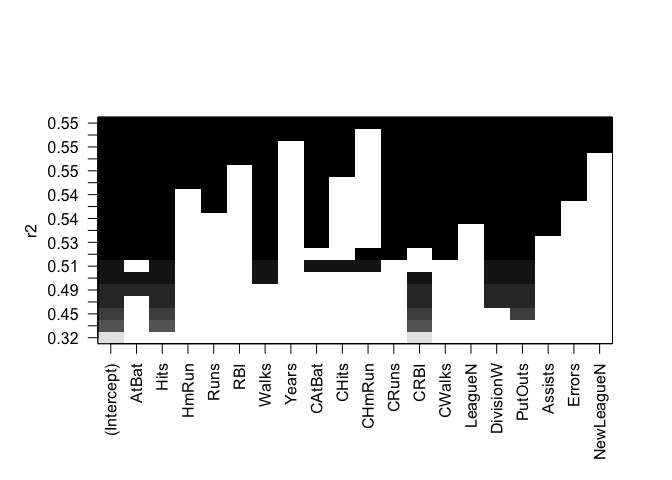

```r
plot(modelbest, scale ="r2")
```

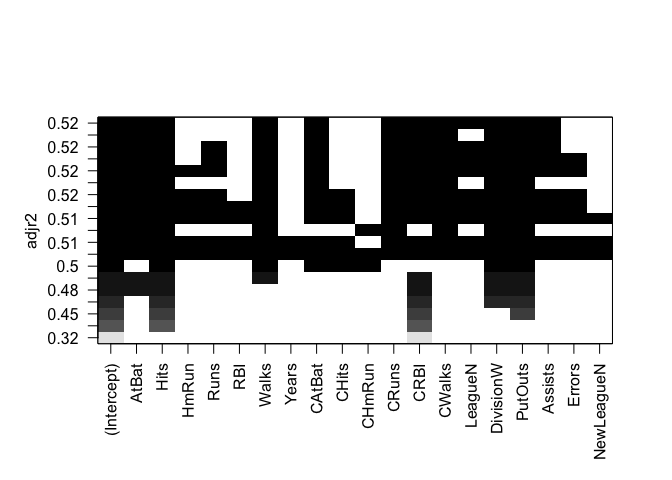

```r
plot(modelbest, scale ="adjr2")
```

```r
names(summary(modelbest))
```

```
## [1] "which"  "rsq"    "rss"    "adjr2"  "cp"     "bic"    "outmat" "obj"
```

```r
summary(modelbest)$rsq
```

```
##  [1] 0.3214501 0.4252237 0.4514294 0.4754067 0.4908036 0.5087146 0.5141227
##  [8] 0.5285569 0.5346124 0.5404950 0.5426153 0.5436302 0.5444570 0.5452164
## [15] 0.5454692 0.5457656 0.5459518 0.5460945 0.5461159
```

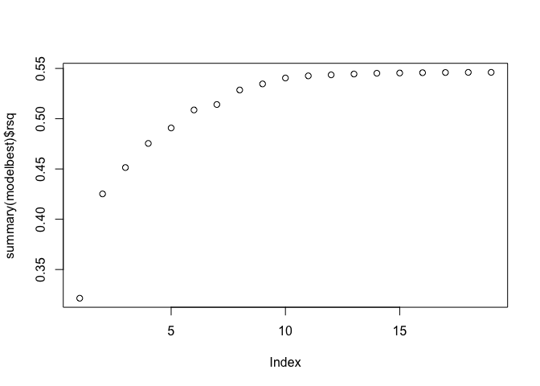

```r
plot(summary(modelbest)$rsq)
```

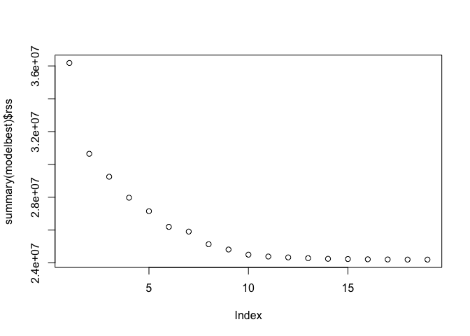

```r
plot(summary(modelbest)$rss)
```

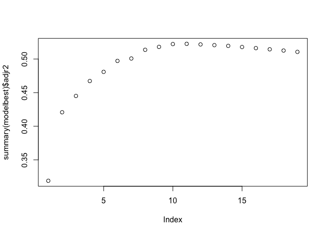

```r
plot(summary(modelbest)$adjr2)
```

```r
which.max(summary(modelbest)$adjr2)
```

```
## [1] 11
```

```r
coef(modelbest,11)
```

```
##  (Intercept)        AtBat         Hits        Walks       CAtBat        CRuns
##  135.7512195   -2.1277482    6.9236994    5.6202755   -0.1389914    1.4553310
##         CRBI       CWalks      LeagueN    DivisionW      PutOuts      Assists
##    0.7852528   -0.8228559   43.1116152 -111.1460252    0.2894087    0.2688277
```

The figures indicate that R-squared increase as the number of variables in the subset increases and likewise the residual sum of squared (sum of squared errors) decreases as the size of the subsets increases. On the other hand the adjusted R-squared increases first and then decreases.

## 2.2 Forward and backward stepwise selection

In this example, the best model identified by the forward step-wise selection method is the same as that obtained by the best subset selection. It is also possible to run this algorithm using a backward step-wise selection method where we drop variables one a time rather add. In general, the solutions from these two methods may be different.

```r
modelfwd<-regsubsets(Salary~.,data=hitters,nvmax=19,method="forward")
which.max(summary(modelfwd)$adjr2)
```

```
## [1] 11
```

```r
coef(modelfwd,11)   ###  same as model best
```

```
##  (Intercept)        AtBat         Hits        Walks       CAtBat        CRuns
##  135.7512195   -2.1277482    6.9236994    5.6202755   -0.1389914    1.4553310
##         CRBI       CWalks      LeagueN    DivisionW      PutOuts      Assists
##    0.7852528   -0.8228559   43.1116152 -111.1460252    0.2894087    0.2688277
```

```r
summary(modelbest)$adjr2-summary(modelfwd)$adjr2
```

```
##  [1]  5.551115e-16  8.881784e-16  3.330669e-16  4.440892e-16  1.110223e-16
##  [6]  1.110223e-16  9.185854e-04  4.314850e-04 -2.220446e-16 -1.110223e-16
## [11]  1.110223e-16  0.000000e+00  0.000000e+00  2.220446e-16  1.110223e-16
## [16]  0.000000e+00  0.000000e+00  0.000000e+00  0.000000e+00
```

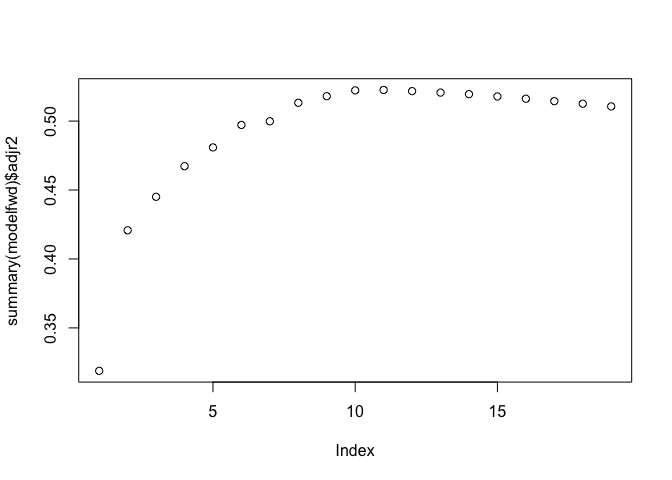

```r
plot(summary(modelfwd)$adjr2)
```

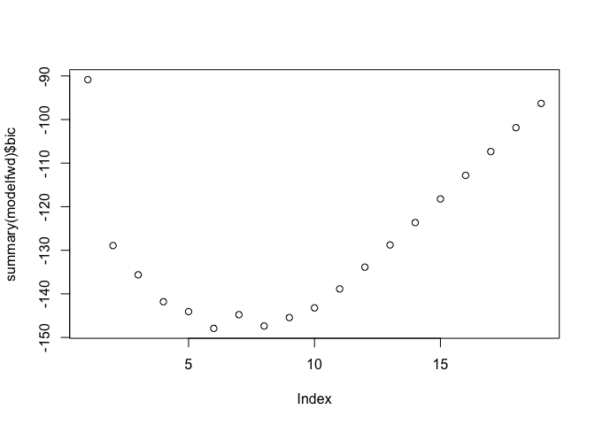

```r
plot(summary(modelfwd)$bic)
```

```r
modelbcwd<-regsubsets(Salary~.,data=hitters,nvmax=19,method="backward")
which.max(summary(modelbcwd)$adjr2)
```

```
## [1] 11
```

```r
coef(modelbcwd,11)
```

```
##  (Intercept)        AtBat         Hits        Walks       CAtBat        CRuns
##  135.7512195   -2.1277482    6.9236994    5.6202755   -0.1389914    1.4553310
##         CRBI       CWalks      LeagueN    DivisionW      PutOuts      Assists
##    0.7852528   -0.8228559   43.1116152 -111.1460252    0.2894087    0.2688277
```

```r
summary(modelbcwd)
```

```
## Subset selection object
## Call: regsubsets.formula(Salary ~ ., data = hitters, nvmax = 19, method = "backward")
## 19 Variables  (and intercept)
##            Forced in Forced out
## AtBat          FALSE      FALSE
## Hits           FALSE      FALSE
## HmRun          FALSE      FALSE
## Runs           FALSE      FALSE
## RBI            FALSE      FALSE
## Walks          FALSE      FALSE
## Years          FALSE      FALSE
## CAtBat         FALSE      FALSE
## CHits          FALSE      FALSE
## CHmRun         FALSE      FALSE
## CRuns          FALSE      FALSE
## CRBI           FALSE      FALSE
## CWalks         FALSE      FALSE
## LeagueN        FALSE      FALSE
## DivisionW      FALSE      FALSE
## PutOuts        FALSE      FALSE
## Assists        FALSE      FALSE
## Errors         FALSE      FALSE
## NewLeagueN     FALSE      FALSE
## 1 subsets of each size up to 19
## Selection Algorithm: backward
##           AtBat Hits HmRun Runs RBI Walks Years CAtBat CHits CHmRun CRuns CRBI
## 1  ( 1 )  " "   " "  " "   " "  " " " "   " "   " "    " "   " "    "*"   " "
## 2  ( 1 )  " "   "*"  " "   " "  " " " "   " "   " "    " "   " "    "*"   " "
## 3  ( 1 )  " "   "*"  " "   " "  " " " "   " "   " "    " "   " "    "*"   " "
## 4  ( 1 )  "*"   "*"  " "   " "  " " " "   " "   " "    " "   " "    "*"   " "
## 5  ( 1 )  "*"   "*"  " "   " "  " " "*"   " "   " "    " "   " "    "*"   " "
## 6  ( 1 )  "*"   "*"  " "   " "  " " "*"   " "   " "    " "   " "    "*"   " "
## 7  ( 1 )  "*"   "*"  " "   " "  " " "*"   " "   " "    " "   " "    "*"   " "
## 8  ( 1 )  "*"   "*"  " "   " "  " " "*"   " "   " "    " "   " "    "*"   "*"
## 9  ( 1 )  "*"   "*"  " "   " "  " " "*"   " "   "*"    " "   " "    "*"   "*"
## 10  ( 1 ) "*"   "*"  " "   " "  " " "*"   " "   "*"    " "   " "    "*"   "*"
## 11  ( 1 ) "*"   "*"  " "   " "  " " "*"   " "   "*"    " "   " "    "*"   "*"
## 12  ( 1 ) "*"   "*"  " "   "*"  " " "*"   " "   "*"    " "   " "    "*"   "*"
## 13  ( 1 ) "*"   "*"  " "   "*"  " " "*"   " "   "*"    " "   " "    "*"   "*"
## 14  ( 1 ) "*"   "*"  "*"   "*"  " " "*"   " "   "*"    " "   " "    "*"   "*"
```

[output cut: 10 more lines]

```
## 5  ( 1 )  " "    " "     " "       "*"     " "     " "    " "
## 6  ( 1 )  " "    " "     "*"       "*"     " "     " "    " "
## 7  ( 1 )  "*"    " "     "*"       "*"     " "     " "    " "
## 8  ( 1 )  "*"    " "     "*"       "*"     " "     " "    " "
## 9  ( 1 )  "*"    " "     "*"       "*"     " "     " "    " "
## 10  ( 1 ) "*"    " "     "*"       "*"     "*"     " "    " "
## 11  ( 1 ) "*"    "*"     "*"       "*"     "*"     " "    " "
## 12  ( 1 ) "*"    "*"     "*"       "*"     "*"     " "    " "
## 13  ( 1 ) "*"    "*"     "*"       "*"     "*"     "*"    " "
## 14  ( 1 ) "*"    "*"     "*"       "*"     "*"     "*"    " "
## 15  ( 1 ) "*"    "*"     "*"       "*"     "*"     "*"    " "
## 16  ( 1 ) "*"    "*"     "*"       "*"     "*"     "*"    " "
## 17  ( 1 ) "*"    "*"     "*"       "*"     "*"     "*"    "*"
## 18  ( 1 ) "*"    "*"     "*"       "*"     "*"     "*"    "*"
## 19  ( 1 ) "*"    "*"     "*"       "*"     "*"     "*"    "*"
```

```r
coef(modelbest,11)
```

```
##  (Intercept)        AtBat         Hits        Walks       CAtBat        CRuns
##  135.7512195   -2.1277482    6.9236994    5.6202755   -0.1389914    1.4553310
##         CRBI       CWalks      LeagueN    DivisionW      PutOuts      Assists
##    0.7852528   -0.8228559   43.1116152 -111.1460252    0.2894087    0.2688277
```

```r
coef(modelfwd,11)
```

```
##  (Intercept)        AtBat         Hits        Walks       CAtBat        CRuns
##  135.7512195   -2.1277482    6.9236994    5.6202755   -0.1389914    1.4553310
##         CRBI       CWalks      LeagueN    DivisionW      PutOuts      Assists
##    0.7852528   -0.8228559   43.1116152 -111.1460252    0.2894087    0.2688277
```

```r
coef(modelbcwd,11)
```

```
##  (Intercept)        AtBat         Hits        Walks       CAtBat        CRuns
##  135.7512195   -2.1277482    6.9236994    5.6202755   -0.1389914    1.4553310
##         CRBI       CWalks      LeagueN    DivisionW      PutOuts      Assists
##    0.7852528   -0.8228559   43.1116152 -111.1460252    0.2894087    0.2688277
```

# 3 Subset selection using validation set

## 3.1 Using a training and a validation set

- Split into training and validation set.
- `model.matrix` creates the **X**-matrix. Then we create a loop to find the coefficients for the best subset of size `i` for `i` running from 1 to 19. We use the coefficients to predict the *Y*-values and compute MSE for the *validation set*. Note that AIC, BIC, etc are not used here.

```r
set.seed(5)
train=sample(c(TRUE ,FALSE), nrow(hitters),rep=TRUE)   ## Training set
valset =(!train)       ## Validation set

model_valset=regsubsets(Salary~.,data=hitters[train ,],nvmax =19)  ### best subset on training set
summary(model_valset)
```

```
## Subset selection object
## Call: regsubsets.formula(Salary ~ ., data = hitters[train, ], nvmax = 19)
## 19 Variables  (and intercept)
##            Forced in Forced out
## AtBat          FALSE      FALSE
## Hits           FALSE      FALSE
## HmRun          FALSE      FALSE
## Runs           FALSE      FALSE
## RBI            FALSE      FALSE
## Walks          FALSE      FALSE
## Years          FALSE      FALSE
## CAtBat         FALSE      FALSE
## CHits          FALSE      FALSE
## CHmRun         FALSE      FALSE
## CRuns          FALSE      FALSE
## CRBI           FALSE      FALSE
## CWalks         FALSE      FALSE
## LeagueN        FALSE      FALSE
## DivisionW      FALSE      FALSE
## PutOuts        FALSE      FALSE
## Assists        FALSE      FALSE
## Errors         FALSE      FALSE
## NewLeagueN     FALSE      FALSE
## 1 subsets of each size up to 19
## Selection Algorithm: exhaustive
##           AtBat Hits HmRun Runs RBI Walks Years CAtBat CHits CHmRun CRuns CRBI
## 1  ( 1 )  " "   " "  " "   " "  " " " "   " "   " "    " "   " "    " "   "*"
## 2  ( 1 )  " "   " "  " "   "*"  " " " "   " "   " "    " "   " "    " "   "*"
## 3  ( 1 )  " "   "*"  " "   " "  " " "*"   " "   " "    " "   " "    " "   "*"
## 4  ( 1 )  " "   "*"  " "   " "  " " "*"   " "   " "    " "   " "    " "   "*"
## 5  ( 1 )  " "   "*"  " "   " "  " " "*"   " "   " "    " "   "*"    "*"   " "
## 6  ( 1 )  "*"   "*"  " "   " "  " " "*"   " "   " "    " "   "*"    "*"   " "
## 7  ( 1 )  "*"   "*"  " "   " "  " " "*"   " "   " "    " "   "*"    "*"   " "
## 8  ( 1 )  "*"   "*"  " "   " "  " " "*"   " "   " "    "*"   " "    "*"   "*"
## 9  ( 1 )  "*"   "*"  " "   " "  " " "*"   " "   " "    "*"   " "    "*"   "*"
## 10  ( 1 ) "*"   "*"  " "   " "  " " "*"   " "   " "    "*"   " "    "*"   "*"
## 11  ( 1 ) "*"   "*"  " "   " "  " " "*"   "*"   " "    "*"   " "    "*"   "*"
## 12  ( 1 ) "*"   "*"  " "   " "  " " "*"   " "   " "    "*"   " "    "*"   "*"
## 13  ( 1 ) "*"   "*"  " "   " "  " " "*"   "*"   " "    "*"   " "    "*"   "*"
## 14  ( 1 ) "*"   "*"  "*"   " "  " " "*"   "*"   " "    "*"   " "    "*"   "*"
```

[output cut: 10 more lines]

```
## 5  ( 1 )  " "    " "     " "       "*"     " "     " "    " "
## 6  ( 1 )  " "    " "     " "       "*"     " "     " "    " "
## 7  ( 1 )  " "    " "     "*"       "*"     " "     " "    " "
## 8  ( 1 )  " "    " "     "*"       "*"     " "     " "    " "
## 9  ( 1 )  "*"    " "     "*"       "*"     " "     " "    " "
## 10  ( 1 ) "*"    " "     "*"       "*"     " "     " "    "*"
## 11  ( 1 ) "*"    " "     "*"       "*"     " "     " "    "*"
## 12  ( 1 ) "*"    " "     "*"       "*"     "*"     "*"    "*"
## 13  ( 1 ) "*"    " "     "*"       "*"     "*"     "*"    "*"
## 14  ( 1 ) "*"    " "     "*"       "*"     "*"     "*"    "*"
## 15  ( 1 ) "*"    " "     "*"       "*"     "*"     "*"    "*"
## 16  ( 1 ) "*"    " "     "*"       "*"     "*"     "*"    "*"
## 17  ( 1 ) "*"    " "     "*"       "*"     "*"     "*"    "*"
## 18  ( 1 ) "*"    " "     "*"       "*"     "*"     "*"    "*"
## 19  ( 1 ) "*"    "*"     "*"       "*"     "*"     "*"    "*"
```

```r
valset.mat=model.matrix(Salary~.,data=hitters[valset,])  ### Creates the X-matrix

valset.mat
```

[output not shown]

[output cut: 256 more lines]

```r
MSE.val =rep(NA ,19)
for(i in 1:19){
  coefi=coef(model_valset, id=i)   ## Selects coefficients of the best subset of size i
  pred=valset.mat[,names(coefi)]%*%coefi  ## Predicts y-values
  MSE.val[i]= mean((hitters$Salary[valset]-pred)^2) ## computes MSE for the model on validation set.
}
```

Let us check the MSE values for the different best subsets.

```r
MSE.val
```

```
##  [1] 150215.6 146425.9 146799.3 140254.5 142505.7 133624.1 129909.2 130839.1
##  [9] 126677.5 126061.8 128898.9 126881.2 129717.7 129608.0 129527.6 129602.1
## [17] 128885.5 129856.6 130404.8
```

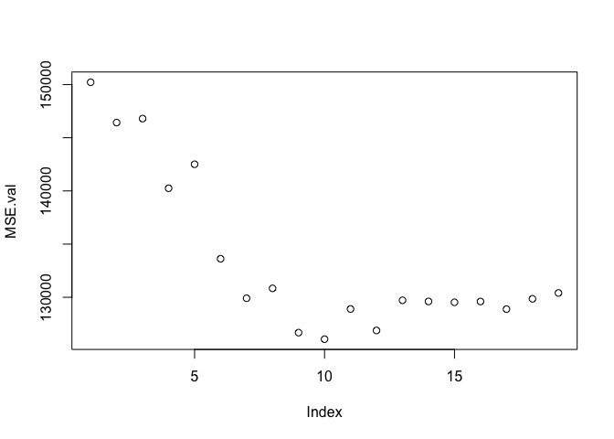

```r
plot(MSE.val)
```

```r
best<-which.min(MSE.val)
best
```

```
## [1] 10
```

The best model turns out to be the one with 10 variables. Notice that if we now look at the best subset of size 10 on the entire data set, it is a bit different.

```r
coef(model_valset,best) #### Coefficients from the entire training set of hitters (without NA values)
```

```
## (Intercept)       AtBat        Hits       Walks       CHits       CRuns
## -57.3166343  -1.1352411   5.6853121   4.3289280  -0.5825003   1.3342097
##        CRBI      CWalks   DivisionW     PutOuts  NewLeagueN
##   0.6996060  -0.2490187 -58.2957815   0.1895886  33.3294093
```

```r
coef(modelbest,best)      #### Coefficients from the entire data set of hitters (without NA values)  # Use names(...) to get the coefficents selected
```

```
##  (Intercept)        AtBat         Hits        Walks       CAtBat        CRuns
##  162.5354420   -2.1686501    6.9180175    5.7732246   -0.1300798    1.4082490
##         CRBI       CWalks    DivisionW      PutOuts      Assists
##    0.7743122   -0.8308264 -112.3800575    0.2973726    0.2831680
```

## 3.2 Prediction

Unfortunately `regsubsets` does not have a `prediction` method in-built. Hence we write a function for prediction.

```r
predict.regsubsets=function(object,newdata,id,...){
  form=as.formula(object$call[[2]])   ### check what this does
  mat=model.matrix(form,newdata)
  coefi=coef(object,id=id)
  xvars =names(coefi)
  mat[,xvars]%*%coefi
}

pred<- predict.regsubsets(model_valset,hitters[valset,],id=best)
MSE.valsetbest<- mean((hitters$Salary[valset]-pred)^2)

MSE.valsetbest
```

```
## [1] 126061.8
```

```r
### Check with MSE calculated  previously
MSE.val[best]
```

```
## [1] 126061.8
```

We will use the `predict.regsubsets` function later.

## 3.3 Subset selection with k-fold cross validation

We now try to choose among the models of different sizes using cross validation. This approach is somewhat involved, as we must perform best subset selection within each of the `k` training sets. Despite this, we see that with its clever subsetting syntax, R makes this job quite easy. First, we create a vector that allocates each observation to one of `k = 10` folds, and we create a matrix in which we will store the results.

```r
k=10
set.seed (1)
folds=sample(1:k,nrow(hitters),replace =TRUE)
cv.errors =matrix(NA,k,19, dimnames=list(NULL, paste(1:19)))
folds
```

```
##   [1]  9  4  7  1  2  7  2  3  1  5  5 10  6 10  7  9  5  5  9  9  5  5  2 10  9
##  [26]  1  4  3  6 10 10  6  4  4 10  9  7  6  9  8  9  7  8  6 10  7  3 10  6  8
##  [51]  2  2  6  6  1  3  3  8  6  7  6  8  7  1  4  8  9  9  7  4  7  6  1  5  6
##  [76]  1  9  7  7  3  6  2 10 10  7  3  2 10  1 10 10  8 10  5  7  8  5  6  8  1
## [101]  3 10  3  1  6  6  4  9  5  1  3  6  3  7  3  3  1  9  2  8  6  1  2  7  7
## [126]  4  9  8  3  5  3  4  2  1  7  9 10 10  2  2  3  1  2  3  3  3  8  9  2 10
## [151]  8 10  4  5  9  5  7  5  6  4  2  1  3  8  9  6  1  4  5  9  5  8  4  1  9
## [176]  5  1  5  4 10 10  9  8  5  5  6  6  2  2  8  4 10  8  5  5  8  8  7  4  4
## [201]  1 10  4  9  9  9  9  6  6  4  3  3  9  9  7  9  5  7  4  4 10  8  1 10  2
## [226] 10  1  1  4  5  5  6  9  8  5  1  2  1  8  5  8 10  7  7  2  9  4  2  5  2
## [251]  4  3  6  9  7  5  5  1  1 10  1  3 10
```

```r
cv.errors
```

```
##        1  2  3  4  5  6  7  8  9 10 11 12 13 14 15 16 17 18 19
##  [1,] NA NA NA NA NA NA NA NA NA NA NA NA NA NA NA NA NA NA NA
##  [2,] NA NA NA NA NA NA NA NA NA NA NA NA NA NA NA NA NA NA NA
##  [3,] NA NA NA NA NA NA NA NA NA NA NA NA NA NA NA NA NA NA NA
##  [4,] NA NA NA NA NA NA NA NA NA NA NA NA NA NA NA NA NA NA NA
##  [5,] NA NA NA NA NA NA NA NA NA NA NA NA NA NA NA NA NA NA NA
##  [6,] NA NA NA NA NA NA NA NA NA NA NA NA NA NA NA NA NA NA NA
##  [7,] NA NA NA NA NA NA NA NA NA NA NA NA NA NA NA NA NA NA NA
##  [8,] NA NA NA NA NA NA NA NA NA NA NA NA NA NA NA NA NA NA NA
##  [9,] NA NA NA NA NA NA NA NA NA NA NA NA NA NA NA NA NA NA NA
## [10,] NA NA NA NA NA NA NA NA NA NA NA NA NA NA NA NA NA NA NA
```

Now we write a for loop that performs cross-validation. In the `j`-th fold, the elements of folds that equal `j` are in the test set, and the remainder are in the training set. We make our predictions for each model size (using our new `predict.regsubsets` function), compute the test errors on the appropriate subset, and store them in the appropriate slot in the matrix `cv.errors`.

```r
for(j in 1:k){
 best.cv=regsubsets(Salary~.,data=hitters[folds !=j,],nvmax =19)
 for(i in 1:19) {
 pred=predict.regsubsets(best.cv,hitters[folds ==j,], id=i)
 cv.errors[j,i]=mean((hitters$Salary[folds ==j]-pred)^2)
 }
}
```

Let us plot the cross-validation errors, i.e. means of 10-fold MSEs for different sizes.

```r
mean.cv.errors =apply(cv.errors ,2, mean)
mean.cv.errors
```

```
##        1        2        3        4        5        6        7        8
## 149821.1 130922.0 139127.0 131028.8 131050.2 119538.6 124286.1 113580.0
##        9       10       11       12       13       14       15       16
## 115556.5 112216.7 113251.2 115755.9 117820.8 119481.2 120121.6 120074.3
##       17       18       19
## 120084.8 120085.8 120403.5
```

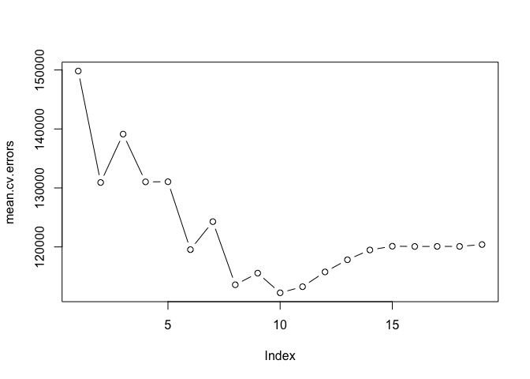

```r
par(mfrow =c(1,1))
plot(mean.cv.errors ,type='b')
```

```r
minb<-which.min(mean.cv.errors)
```

Observe that cross-validation selects a 10-variable model. We now perform best subset selection on the full data set in order to obtain the 10-variable model and compare (which we had already done previously).

```r
coef(modelbest,minb)
```

```
##  (Intercept)        AtBat         Hits        Walks       CAtBat        CRuns
##  162.5354420   -2.1686501    6.9180175    5.7732246   -0.1300798    1.4082490
##         CRBI       CWalks    DivisionW      PutOuts      Assists
##    0.7743122   -0.8308264 -112.3800575    0.2973726    0.2831680
```

*I believe this implementation does not actually give you the best model using cross-validation. Why?*

# 4 LASSO: another subset selection technique

The generalized linear model with penalized maximum likelihood package `glmnet` in R implements the LASSO method. To run the `glmnet()` function, we need to pass in the arguments as *X* (input matrix), *y* (output vector), rather than the *y~X* format that we used thus far. The `model.matrix()` function produces a matrix corresponding to the 19 predictors and the intercept and helps transform qualitative variables into dummy quantitative variables. This is important since `glmnet()` works only with quantitative variables.

```r
#install.packages("glmnet")
library(glmnet)
X <- model.matrix(Salary~.,hitters)
y <- hitters$Salary
str(X)
```

```
##  num [1:263, 1:20] 1 1 1 1 1 1 1 1 1 1 ...
##  - attr(*, "dimnames")=List of 2
##   ..$ : chr [1:263] "2" "3" "4" "5" ...
##   ..$ : chr [1:20] "(Intercept)" "AtBat" "Hits" "HmRun" ...
##  - attr(*, "assign")= int [1:20] 0 1 2 3 4 5 6 7 8 9 ...
##  - attr(*, "contrasts")=List of 3
##   ..$ League   : chr "contr.treatment"
##   ..$ Division : chr "contr.treatment"
##   ..$ NewLeague: chr "contr.treatment"
```

We now choose a range for the lambda parameters and create a training and test set. We then build the LASSO model on this data. The output from the model provides the `Df` (number of non-zero coefficients), `%Dev` and `Lambda` values. The deviance measure is given as `2(loglike_sat - loglike)`, where `loglike_sat` is the log-likelihood for the saturated model (a model with a free parameter per observation). Null deviance is defined to be `2(loglike_sat - loglike(NULL))` where the NULL model refers to the intercept model only. The deviance ratio is `dev.ratio=1-deviance/nulldev`. As `lambda` decreases, the `dev.ratio` increases (more importance given to model fit than model complexity).

```r
?glmnet
grid<-10^seq(10,-2, length=100)
set.seed(1)
train <- sample(1:nrow(X),nrow(X)/2)
test <- -train
modellasso <- glmnet(X[train,],y[train],lambda=grid)
summary(modellasso)
```

```
##           Length Class     Mode
## a0         100   -none-    numeric
## beta      2000   dgCMatrix S4
## df         100   -none-    numeric
## dim          2   -none-    numeric
## lambda     100   -none-    numeric
## dev.ratio  100   -none-    numeric
## nulldev      1   -none-    numeric
## npasses      1   -none-    numeric
## jerr         1   -none-    numeric
## offset       1   -none-    logical
## call         4   -none-    call
## nobs         1   -none-    numeric
```

```r
modellasso
```

```
##
## Call:  glmnet(x = X[train, ], y = y[train], lambda = grid)
##
##     Df  %Dev    Lambda
## 1    0  0.00 1.000e+10
## 2    0  0.00 7.565e+09
## 3    0  0.00 5.722e+09
## 4    0  0.00 4.329e+09
## 5    0  0.00 3.275e+09
## 6    0  0.00 2.477e+09
## 7    0  0.00 1.874e+09
## 8    0  0.00 1.417e+09
## 9    0  0.00 1.072e+09
## 10   0  0.00 8.111e+08
## 11   0  0.00 6.136e+08
```

[output cut: 89 more lines]

```r
deviance(modellasso)
```

```
##   [1] 23667021 23667021 23667021 23667021 23667021 23667021 23667021 23667021
##   [9] 23667021 23667021 23667021 23667021 23667021 23667021 23667021 23667021
##  [17] 23667021 23667021 23667021 23667021 23667021 23667021 23667021 23667021
##  [25] 23667021 23667021 23667021 23667021 23667021 23667021 23667021 23667021
##  [33] 23667021 23667021 23667021 23667021 23667021 23667021 23667021 23667021
##  [41] 23667021 23667021 23667021 23667021 23667021 23667021 23667021 23667021
##  [49] 23667021 23667021 23667021 23667021 23667021 23667021 23667021 23667021
##  [57] 23667021 23667021 23667021 23667021 23667021 23667021 23667021 21493596
##  [65] 18448591 16004435 14536141 13513584 12762702 12245648 11927561 11686083
##  [73] 11491020 11326290 11097815 10986274 10893993 10768183 10653596 10564248
##  [81] 10318467 10131203 10018387  9939979  9884276  9860097  9846001  9837861
##  [89]  9822121  9811413  9804973  9801069  9798650  9797130  9796148  9795507
##  [97]  9795081  9794787  9794588  9794444
```

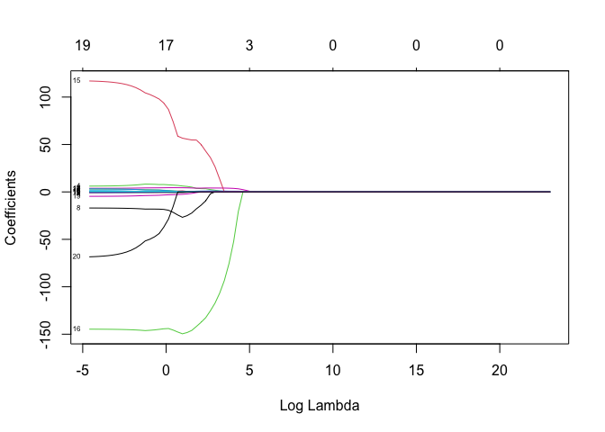

```r
plot(modellasso,xvar="lambda",label="TRUE")
```

We see from the plot that as lambda increases, many of the coefficients get close to zero. We can retrieve these coefficients as follows. Note that the number of non-zero coefficients does not change in a fully monotonic way, as lambda increases or decreases.

```r
modellasso$df
```

```
##   [1]  0  0  0  0  0  0  0  0  0  0  0  0  0  0  0  0  0  0  0  0  0  0  0  0  0
##  [26]  0  0  0  0  0  0  0  0  0  0  0  0  0  0  0  0  0  0  0  0  0  0  0  0  0
##  [51]  0  0  0  0  0  0  0  0  0  0  0  0  0  1  2  3  3  4  7  8  8 10 10 11 10
##  [76] 10 12 12 13 14 14 15 16 17 16 16 17 19 19 19 19 19 19 19 19 19 19 19 19 19
```

```r
#modellasso$beta!=0
#coef.glmnet(modellasso,s=100)
```

## 4.1 Prediction

Predictions: We start with a prediction for the model fitted with different values of `lambda`.

```r
#modellasso$lambda
predictlasso1 <- predict(modellasso,newx=X[test,],s=100)
mse100<-mean((predictlasso1-y[test])^2)


predictlasso2 <- predict(modellasso,newx=X[test,],s=50)
mse50<-mean((predictlasso2-y[test])^2)


predictlasso3 <- predict(modellasso,newx=X[test,],s=200)
mse200<-mean((predictlasso3-y[test])^2)

mse100
```

```
## [1] 151898.3
```

```r
mse50
```

```
## [1] 144900
```

```r
mse200
```

```
## [1] 183422.8
```

```r
?predict.glmnet
predictlasso1a <- predict(modellasso,newx=X[test,],s=100,exact=T,x=X[train,],y=y[train])
mse100e<-mean((predictlasso1a-y[test])^2)
predictlasso2a <- predict(modellasso,newx=X[test,],s=50,exact=T,x=X[train,],y=y[train])
mse50e<-mean((predictlasso2a-y[test])^2)
predictlasso3a <- predict(modellasso,newx=X[test,],s=200,exact=T,x=X[train,],y=y[train])
mse200e<-mean((predictlasso3a-y[test])^2)
predictlasso4 <- predict(modellasso,newx=X[test,],s=0,exact=T,x=X[train,],y=y[train])
mse0e<-mean((predictlasso4-y[test])^2)
predictlasso5 <- predict(modellasso,newx=X[test,],s=10^10,exact=T,x=X[train,],y=y[train])
mse10t10e<-mean((predictlasso5-y[test])^2)



mse100
```

```
## [1] 151898.3
```

```r
mse100e
```

```
## [1] 151898.3
```

```r
mse50
```

```
## [1] 144900
```

```r
mse50e
```

```
## [1] 145013.4
```

```r
mse200
```

```
## [1] 183422.8
```

```r
mse200e
```

```
## [1] 183132.6
```

```r
mse0e
```

```
## [1] 166929.8
```

```r
mse10t10e
```

```
## [1] 224669.9
```

The test mean squared error for this model is 1.5189828^{5}. Suppose, we change lambda to 50, we get 1.4490004^{5} and if we change lambda to 200, we get 1.8342282^{5}. Note that by default if prediction is done at lambda values that are not tried in the fitting algorithm, it uses linear interpolation to make predictions. We can use exact=T in the argument to get the exact value by refitting. In addition, we need to then pass also the original training set data to the function. We get a test error of 1.6692981^{5} with the full model while 2.2466991^{5} with a very large value of lambda. Thus choosing lambda appropriately will be important in the quality of the fit. This can be done with cross-validation.

*Cross-validation:* We use `cv.glmnet` to perform cross-validation to obtain an optimal `lambda`. By default, we perform 10 fold cross validation. Note that `glmnet` uses randomization in choosing the folds which we should be able to control better by setting the seed to be the same.

```r
set.seed(1)
?cv.glmnet
cvlasso <- cv.glmnet(X[train,],y[train])
cvlasso$glmnet.fit  ### glmfit on entire data
```

```
##
## Call:  glmnet(x = X[train, ], y = y[train])
##
##     Df  %Dev  Lambda
## 1    0  0.00 264.500
## 2    1  6.57 241.000
## 3    1 12.03 219.600
## 4    2 16.64 200.100
## 5    2 20.51 182.300
## 6    3 24.00 166.100
## 7    3 27.88 151.400
## 8    3 31.11 137.900
## 9    3 33.78 125.700
## 10   3 36.00 114.500
## 11   3 37.85 104.300
```

[output cut: 89 more lines]

```r
optlambda<- cvlasso$lambda.min
optlambda
```

```
## [1] 9.286955
```

The optimal value of lambda found from cross validation is 9.2869547. You can plot the lambda parameter with the cross-validated mean error (cvm). We see that the best fit from model with the optimal lambda gives a much smaller error on the test set than the model which is based on complete linear regression or the model with only an intercept. We can print out the coefficients to identify that 10 variables are chosen (excluding the intercept).

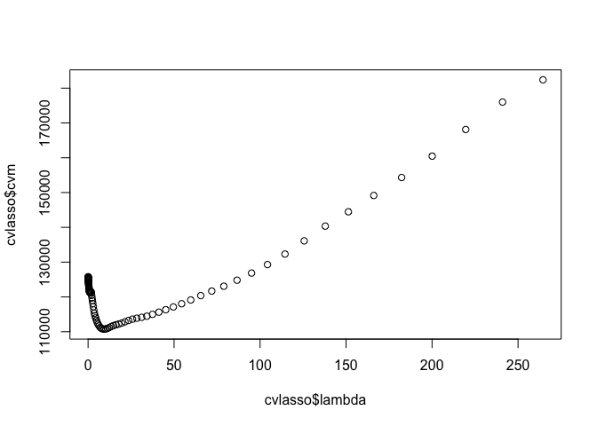

```r
plot(cvlasso$lambda,cvlasso$cvm)  ### mean cross-validated error
```

```r
predictlassocv <- predict(modellasso,s=optlambda,newx=X[test,])
mean((predictlassocv-y[test])^2)
```

```
## [1] 143673.6
```

```r
coef(modellasso,s=optlambda)
```

```
## 21 x 1 sparse Matrix of class "dgCMatrix"
##                       s1
## (Intercept)  120.2583602
## (Intercept)    .
## AtBat          .
## Hits           .
## HmRun          3.4116601
## Runs           .
## RBI            .
## Walks          4.0452228
## Years        -11.9249818
## CAtBat         .
## CHits          0.2064590
## CHmRun         0.9148727
## CRuns          .
## CRBI           0.3830162
## CWalks         .
## LeagueN       46.8537301
## DivisionW   -135.2895145
## PutOuts        0.1164928
## Assists        0.1399019
## Errors         .
## NewLeagueN     .
```

```r
coef(modelbest,8)
```

```
##  (Intercept)        AtBat         Hits        Walks       CHmRun        CRuns
##  130.9691577   -2.1731903    7.3582935    6.0037597    1.2339718    0.9651349
##       CWalks    DivisionW      PutOuts
##   -0.8323788 -117.9657795    0.2908431
```

Note that this does not choose the same model as best subset.